# Report

Brian Omachi

2/21/2022

## Data reading and cleaning

```r
knitr::opts_chunk$set(echo = TRUE)
## Libraries
library(dplyr)
library(tidyverse)
library(plyr)
```

```r
## Read the data files
# Kenya Data
kenya_orders <- read.csv('D:/Documents/freelance/topmama/Data Dumps/Kenya Orders.csv')
kenya_customers <- read.csv('D:/Documents/freelance/topmama/Data Dumps/Kenya Customers.csv')
kenya_deliveries <- read.csv('D:/Documents/freelance/topmama/Data Dumps/Kenya Deliveries.csv')

# Nigeria Data
nigeria_orders <- read.csv('D:/Documents/freelance/topmama/Data Dumps/Nigeria Orders.csv')
nigeria_customers <- read.csv('D:/Documents/freelance/topmama/Data Dumps/Nigeria Customers.csv')
nigeria_deliveries <- read.csv('D:/Documents/freelance/topmama/Data Dumps/Nigeria Deliveries.csv')

### Removing unnecessary characters within the deliveries data
kenya_deliveries$Order_ID = substring(kenya_deliveries$Order_ID, 4)
kenya_deliveries$Order_ID = substr(kenya_deliveries$Order_ID,1,nchar(kenya_deliveries$Order_ID)-2)
nigeria_deliveries$Order_ID = substring(nigeria_deliveries$Order_ID, 4)
nigeria_deliveries$Order_ID = substr(nigeria_deliveries$Order_ID,1,nchar(nigeria_deliveries$Order_ID)-2)

## Data Merging to one file per country
# Kenya
kenya_deliveries$Order_ID = strtoi(kenya_deliveries$Order_ID)
kenya_data <- left_join(kenya_deliveries, kenya_orders,
                          by = c("Order_ID"="Order.ID"))
kenya_data <- left_join(kenya_data, kenya_customers,
                        by = c("Customer.ID"="Customer.ID"))
kenya_data$Country = 'KE'

# Nigeria
nigeria_deliveries$Order_ID = strtoi(nigeria_deliveries$Order_ID)
nigeria_data <- left_join(nigeria_deliveries, nigeria_orders,
                        by = c("Order_ID"="Order.ID"))
nigeria_data <- left_join(nigeria_data, nigeria_customers,
                        by = c("Customer.ID"="Customer.ID"))
nigeria_data$Country = 'NG'

### Row binding the 2 dataframes into 1 file
names(nigeria_data)[names(nigeria_data) == 'Number.of.Employees'] <- 'Number.of.employees'
all_data <- rbind.fill(kenya_data, nigeria_data)

#### Data Cleaning
## Remove columns with 50% or more missing values
new_all_data <- all_data[, which(colMeans(!is.na(all_data)) >= 0.5)]

# Removing duplicates based on the order id column
new_all_data <- new_all_data[!duplicated(new_all_data$Order_ID), ]

# Remove unrequired columns based on frequencies
new_all_data[ ,c('Review', 'Order.Preparation.Time','Debt.Amount','Flat.Discount','Checkout.Template.Name',
                        'Checkout.Template.Value','Last.Used.Platform','Is.Blocked','Language','Outstanding.Amount',
                        'Upload.restuarant.location', 'Taxable.Amount','Additional.Charge','Promo_Applied','X','Pricing',
                 'Earning','Task_Category','Tip.y','Tip.x','Discount.y','Delivery_Charges','Delivery.Charge','Tax','Ref_Images',
                 'X.1','Transaction.ID','Remaining.Balance')] <- list(NULL)

### Total_Time_Taken.min, Task_Details_QTY, Unit.Price, Cost.Price, Total.Price, Order.Total,Sub.Total, Distance..in.km.,
### Redeemed.Loyalty.Points, Consumed.Loyalty.Points, Country, Loyalty.Points, Category.Name
## Factors - Country and Category.Name

### Linear regression for loyalty-points prediction  - No EDA done but diagnostics checked
lm_data <- new_all_data %>% select(Total_Time_Taken.min., Task_Details_QTY, Unit.Price, Cost.Price, Total.Price,
                                   Order.Total,Sub.Total, Distance..in.km.,Redeemed.Loyalty.Points, Consumed.Loyalty.Points,
                                   Loyalty.Points,Country, Category.Name)
lm_data_1 <- sapply(lm_data[,1:(length(lm_data)-2)],as.numeric)
lm_data_2 <- cbind(lm_data_1,lm_data[,(length(lm_data)-1):length(lm_data)])
lm_data_2$Category.Name = as.factor(lm_data$Category.Name)
lm_data_2$Country = as.factor(lm_data$Country)

## Modelling Data - Filter into separate countries
ke_model_data <- lm_data_2 %>% filter(Country=='KE')
drop <- c("Country")
ke_model_data = ke_model_data[,!(names(ke_model_data) %in% drop)]
ng_model_data <- lm_data_2 %>% filter(Country=='NG')
ng_model_data = ng_model_data[,!(names(ng_model_data) %in% drop)]
```

## Statistical Objective

Though not having a lot of information on the data, it is notable that the main KPIs revolve around customer retention, churn, loyalty and revenue optimization. In undertaking the task, I was to do a classification model to assist in the prediction of retention or churn of clients in its categorical form but given the variables available and my customer-centric interest, I decided to perform a linear regression model to come up with a model for prediction of loyalty points given other existent variables. With these decision comes some disclaimer/assumptions: 1. Apart from considering standard data norms such as ignoring variables with high proportions of missing observations, I also purposefully picked variable which I assumed to affect the dependent variable in this case loyalty points 2. The models done are not based on any EDA process and therefore there is deemed to be some biasness with regards to aspects such as multicollinearity 3. Performed country based modelling with the assumption of different product modalities 4. Only adjusted R square considered for model validation

## Kenya Prediction Model

```r
library(MASS)
model_1 <- lm(Loyalty.Points~., data=ke_model_data)
summary(model_1)
```

```
##
## Call:
## lm(formula = Loyalty.Points ~ ., data = ke_model_data)
##
## Residuals:
##     Min      1Q  Median      3Q     Max
## -1328.5  -271.2  -154.2   103.6  2698.1
##
## Coefficients:
##                                    Estimate Std. Error t value Pr(>|t|)
## (Intercept)                       1.020e+02  1.028e+02   0.992 0.321115
## Total_Time_Taken.min.            -1.137e-01  6.908e-02  -1.646 0.099879 .
## Task_Details_QTY                 -1.014e+01  6.082e+00  -1.667 0.095696 .
## Unit.Price                        1.880e+00  3.168e-01   5.935 3.49e-09 ***
## Cost.Price                       -1.876e+00  3.224e-01  -5.820 6.90e-09 ***
## Total.Price                       1.152e-02  2.797e-03   4.117 3.99e-05 ***
## Order.Total                       5.838e-01  1.624e-01   3.596 0.000332 ***
## Sub.Total                         1.001e+00  4.322e-01   2.315 0.020711 *
## Distance..in.km.                 -4.793e-02  3.739e-02  -1.282 0.199988
## Redeemed.Loyalty.Points           6.069e-01  1.802e-01   3.367 0.000775 ***
## Consumed.Loyalty.Points          -1.575e+02  4.049e+01  -3.891 0.000103 ***
## Category.NameCleaning & Hygiene   2.284e+02  1.542e+02   1.481 0.138699
## Category.NameCooking Fat & Oil   -8.224e+01  1.068e+02  -0.770 0.441324
## Category.NameFlour & Sugar        1.773e+00  1.015e+02   0.017 0.986064
## Category.NameFruits & Vegetables  4.802e+02  1.315e+02   3.651 0.000268 ***
## Category.NameMeat & Fish          3.699e+01  1.201e+02   0.308 0.758135
## Category.NamePackaging            7.844e+01  1.728e+02   0.454 0.649967
## Category.NameRice & Cereals      -2.023e+02  1.273e+02  -1.589 0.112203
## Category.NameSalt & Seasoning     1.717e+02  1.232e+02   1.394 0.163572
## Category.NameSpreads              4.923e+02  2.497e+02   1.972 0.048766 *
## ---
## Signif. codes:  0 '***' 0.001 '**' 0.01 '*' 0.05 '.' 0.1 ' ' 1
##
## Residual standard error: 510.8 on 1916 degrees of freedom
##   (18670 observations deleted due to missingness)
## Multiple R-squared:  0.1901, Adjusted R-squared:  0.182
## F-statistic: 23.66 on 19 and 1916 DF,  p-value: < 2.2e-16
```

```r
step.model <- stepAIC(model_1, direction = "both",
                      trace = FALSE)
summary(step.model)
```

```
##
## Call:
## lm(formula = Loyalty.Points ~ Total_Time_Taken.min. + Task_Details_QTY +
##     Unit.Price + Cost.Price + Total.Price + Order.Total + Sub.Total +
##     Redeemed.Loyalty.Points + Consumed.Loyalty.Points + Category.Name,
##     data = ke_model_data)
##
## Residuals:
##     Min      1Q  Median      3Q     Max
## -1328.5  -270.6  -153.3   103.1  2698.4
##
## Coefficients:
##                                    Estimate Std. Error t value Pr(>|t|)
## (Intercept)                       1.014e+02  1.028e+02   0.986 0.324027
## Total_Time_Taken.min.            -1.154e-01  6.908e-02  -1.671 0.094892 .
## Task_Details_QTY                 -1.019e+01  6.083e+00  -1.676 0.093979 .
## Unit.Price                        1.862e+00  3.165e-01   5.881 4.80e-09 ***
## Cost.Price                       -1.858e+00  3.221e-01  -5.769 9.30e-09 ***
## Total.Price                       1.165e-02  2.796e-03   4.167 3.22e-05 ***
## Order.Total                       5.860e-01  1.624e-01   3.609 0.000315 ***
## Sub.Total                         1.023e+00  4.319e-01   2.369 0.017917 *
## Redeemed.Loyalty.Points           6.100e-01  1.803e-01   3.384 0.000729 ***
## Consumed.Loyalty.Points          -1.600e+02  4.045e+01  -3.957 7.88e-05 ***
## Category.NameCleaning & Hygiene   2.287e+02  1.542e+02   1.483 0.138185
## Category.NameCooking Fat & Oil   -8.037e+01  1.068e+02  -0.753 0.451829
## Category.NameFlour & Sugar        2.227e+00  1.015e+02   0.022 0.982501
## Category.NameFruits & Vegetables  4.813e+02  1.315e+02   3.659 0.000260 ***
## Category.NameMeat & Fish          3.793e+01  1.201e+02   0.316 0.752185
## Category.NamePackaging            7.852e+01  1.729e+02   0.454 0.649686
## Category.NameRice & Cereals      -1.987e+02  1.273e+02  -1.561 0.118674
## Category.NameSalt & Seasoning     1.716e+02  1.232e+02   1.393 0.163801
## Category.NameSpreads              4.951e+02  2.497e+02   1.982 0.047569 *
## ---
## Signif. codes:  0 '***' 0.001 '**' 0.01 '*' 0.05 '.' 0.1 ' ' 1
##
## Residual standard error: 510.9 on 1917 degrees of freedom
##   (18670 observations deleted due to missingness)
## Multiple R-squared:  0.1894, Adjusted R-squared:  0.1818
## F-statistic: 24.88 on 18 and 1917 DF,  p-value: < 2.2e-16
```

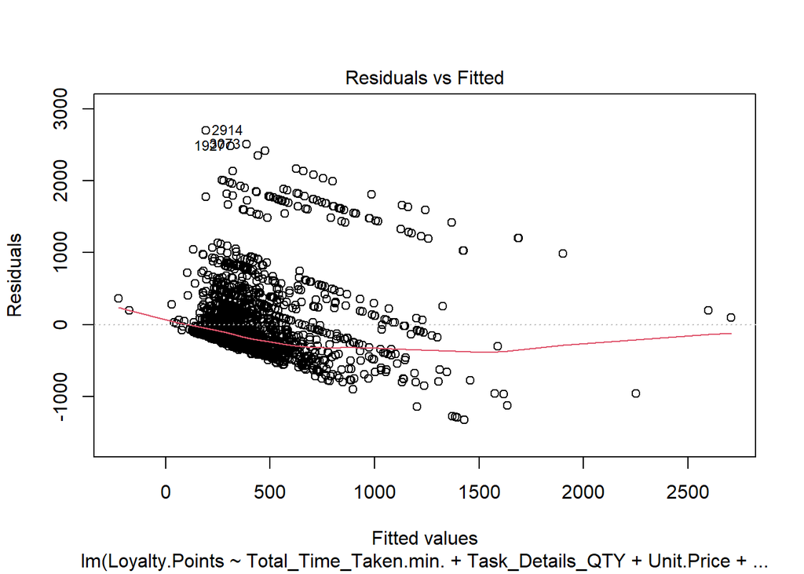

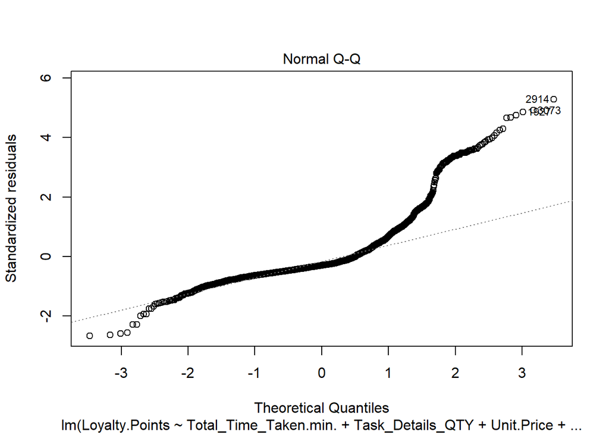

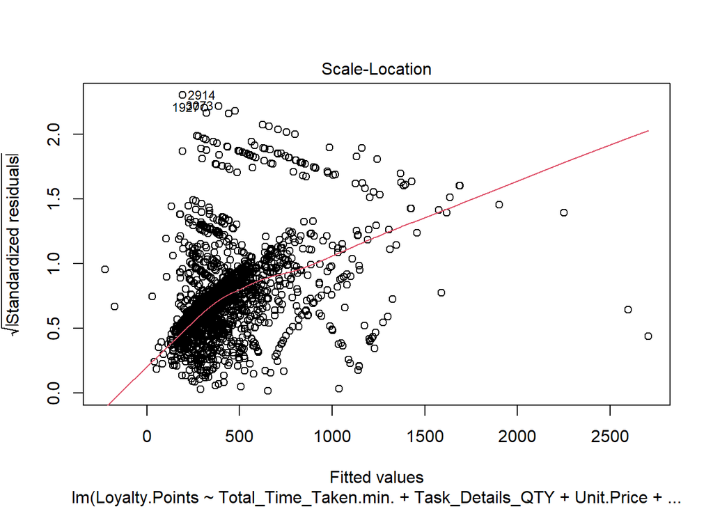

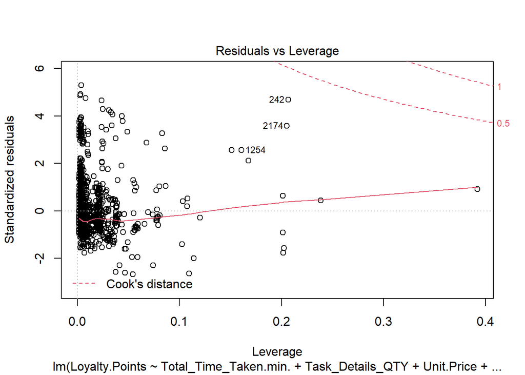

```r
plot(step.model)
```

From the model above some of the notable variables which significantly affect the dependent variable. These are unit price, cost price, total price, order total, sub total, consumed and redeemed loyalty points, Fruits and vegetables and spreads. The model created is not very strong since it only accounts for 19% of the variation within the dependent variable. From the diagnostic plots there is little normality and there is no perfect homoscedasticity as shown by the scale location variable.

## Nigeria Prediction Model

```r
model_2 <- lm(Loyalty.Points~., data=ng_model_data)
summary(model_2)
```

```
##
## Call:
## lm(formula = Loyalty.Points ~ ., data = ng_model_data)
##
## Residuals:
##     Min      1Q  Median      3Q     Max
## -5681.9 -1658.1  -290.4  1709.4 15318.2
##
## Coefficients:
##                                    Estimate Std. Error t value Pr(>|t|)
## (Intercept)                       1.553e+06  1.023e+06   1.519   0.1301
## Total_Time_Taken.min.            -2.560e-01  1.704e+00  -0.150   0.8807
## Task_Details_QTY                 -6.614e+01  7.312e+01  -0.905   0.3667
## Unit.Price                       -2.096e-01  3.674e-01  -0.570   0.5690
## Cost.Price                        2.523e-01  3.863e-01   0.653   0.5143
## Total.Price                       7.668e-03  4.731e-03   1.621   0.1064
## Order.Total                      -3.372e+00  2.968e+00  -1.136   0.2572
## Sub.Total                         2.457e-01  3.261e+00   0.075   0.9400
## Distance..in.km.                 -1.292e+02  8.516e+01  -1.518   0.1305
## Redeemed.Loyalty.Points          -1.647e+01  1.485e+01  -1.109   0.2687
## Consumed.Loyalty.Points           1.563e+03  6.448e+02   2.424   0.0161 *
## Category.NameCooking Fat & Oil   -2.292e+03  2.900e+03  -0.790   0.4301
## Category.NameFlour & Sugar       -2.630e+02  2.814e+03  -0.093   0.9256
## Category.NameNoodles & Spaghetti -1.586e+03  2.939e+03  -0.540   0.5900
## Category.NameRice & Cereals      -1.763e+03  2.945e+03  -0.599   0.5500
## Category.NameVegetables          -2.603e+03  3.903e+03  -0.667   0.5056
## ---
## Signif. codes:  0 '***' 0.001 '**' 0.01 '*' 0.05 '.' 0.1 ' ' 1
##
## Residual standard error: 2621 on 225 degrees of freedom
##   (5184 observations deleted due to missingness)
## Multiple R-squared:  0.3128, Adjusted R-squared:  0.267
## F-statistic: 6.828 on 15 and 225 DF,  p-value: 3.991e-12
```

```r
step.model_2 <- stepAIC(model_2, direction = "both",
                      trace = FALSE)
summary(step.model_2)
```

```
##
## Call:
## lm(formula = Loyalty.Points ~ Task_Details_QTY + Unit.Price +
##     Cost.Price + Total.Price + Order.Total + Distance..in.km. +
##     Redeemed.Loyalty.Points + Consumed.Loyalty.Points, data = ng_model_data)
##
## Residuals:
##     Min      1Q  Median      3Q     Max
## -6111.5 -1905.4  -361.1  1866.1 15118.6
##
## Coefficients:
##                           Estimate Std. Error t value Pr(>|t|)
## (Intercept)              1.848e+06  8.791e+05   2.102  0.03666 *
## Task_Details_QTY        -1.118e+02  6.412e+01  -1.744  0.08253 .
## Unit.Price              -6.013e-01  3.027e-01  -1.986  0.04816 *
## Cost.Price               6.574e-01  3.283e-01   2.003  0.04638 *
## Total.Price              1.159e-02  4.285e-03   2.705  0.00734 **
## Order.Total             -3.757e+00  1.139e+00  -3.299  0.00112 **
## Distance..in.km.        -1.538e+02  7.328e+01  -2.099  0.03692 *
## Redeemed.Loyalty.Points -1.862e+01  5.687e+00  -3.274  0.00122 **
## Consumed.Loyalty.Points  1.878e+03  5.696e+02   3.297  0.00113 **
## ---
## Signif. codes:  0 '***' 0.001 '**' 0.01 '*' 0.05 '.' 0.1 ' ' 1
##
## Residual standard error: 2622 on 232 degrees of freedom
##   (5184 observations deleted due to missingness)
## Multiple R-squared:  0.2911, Adjusted R-squared:  0.2667
## F-statistic: 11.91 on 8 and 232 DF,  p-value: 3.326e-14
```

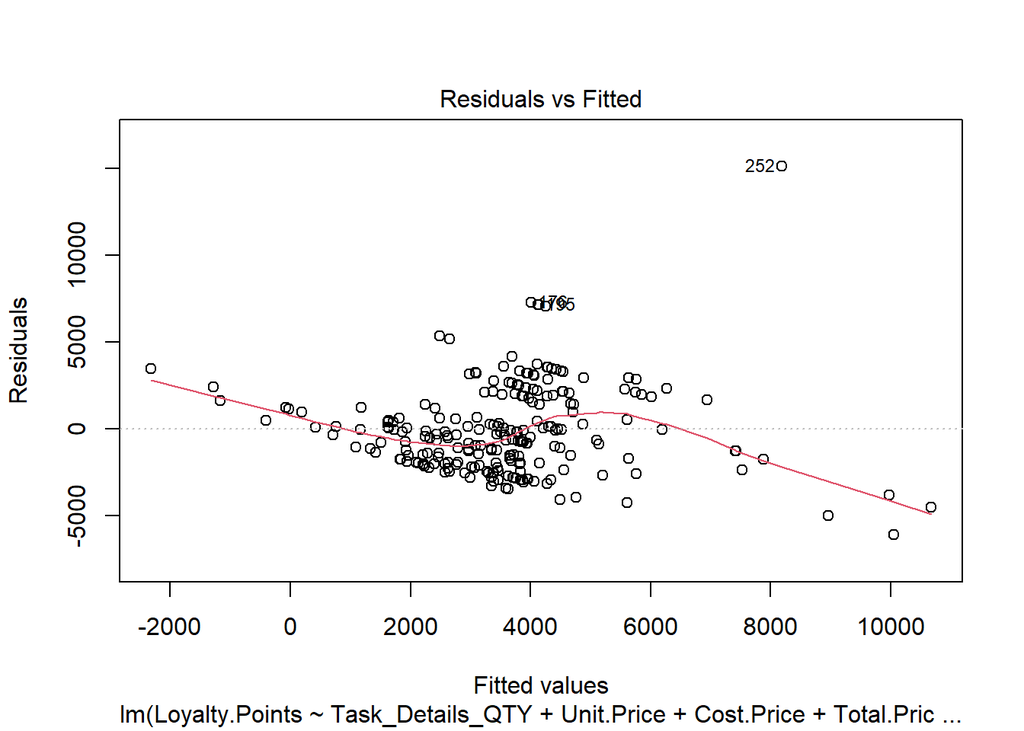

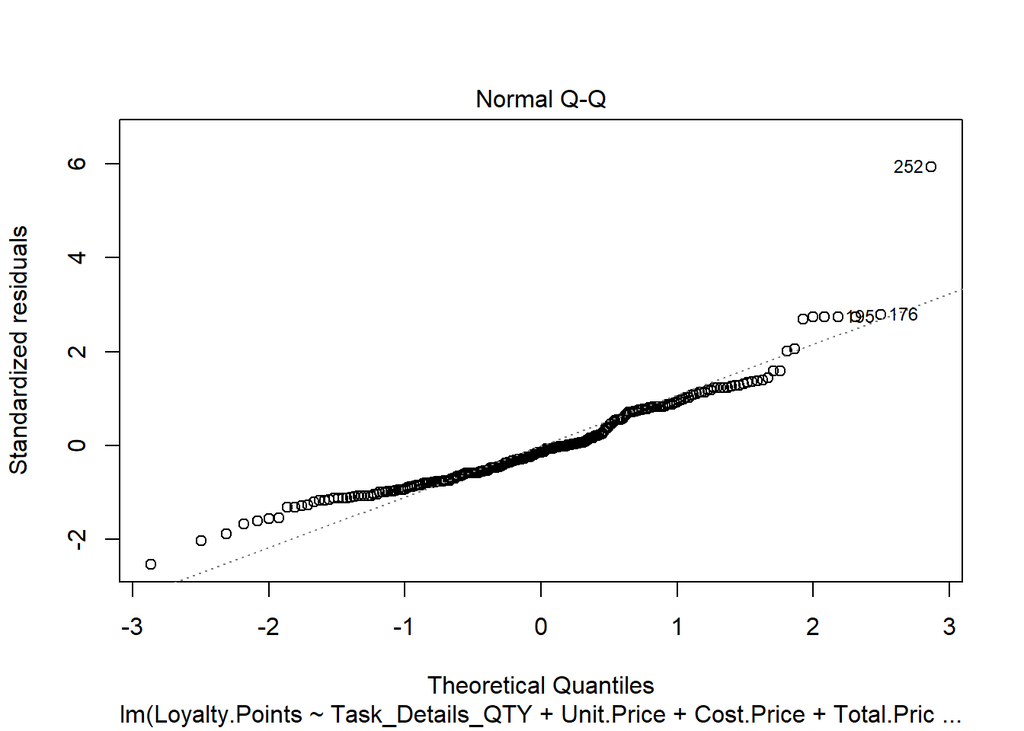

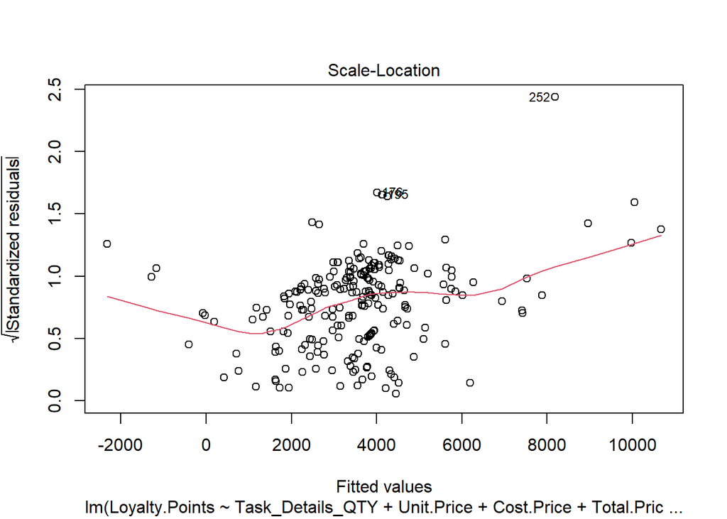

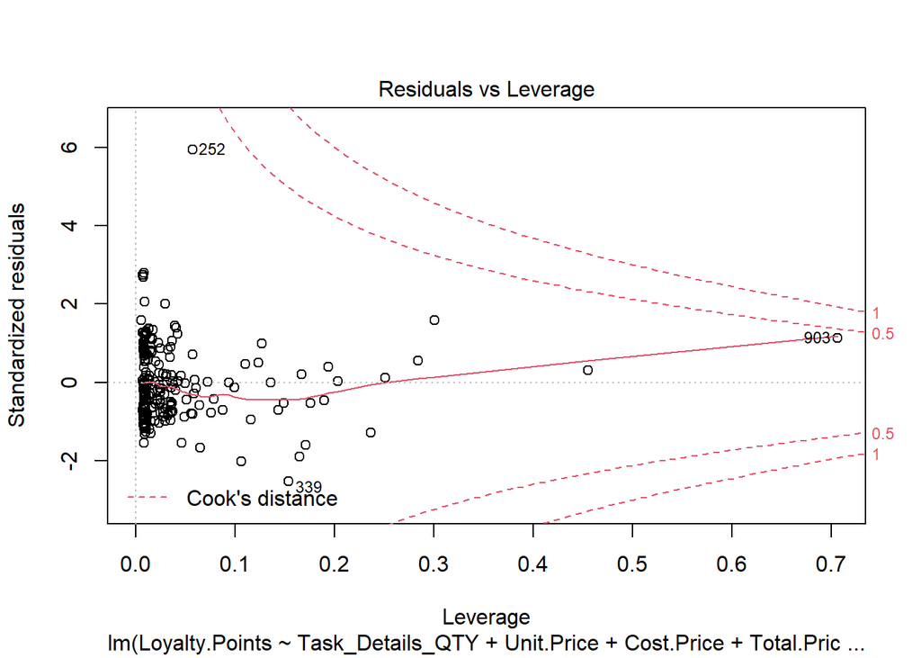

```r
plot(step.model_2)
```